# OMG finally

We will finally analyse this data properly.

# We need to clean up a bit for the new files:

I looked at the GWAS Catalog’s description of their ancestry curation, and I still don’t know what to do with the samples that Amanda has, because I would argue that this is genetic ancestry, poorly described, which is not necessarily the case for the other two datasets. But it also has a bunch of terms that are clearly racial in origin and inspiration, so, like… dunno what to do here.

```r
unique(dbGapFinal$variable) # This is really a horrible mix of both, but I guess primarily of geography terms, so I'm making it a new colour scheme... Set 3 here we go
```

```
## [1] Other                            HispanicB                        Other Asian or\nPacific Islander European                         African American
## [6] HispanicA                        South Asian                      East Asian                       African
## Levels: African African American East Asian European HispanicA HispanicB Other Other Asian or\nPacific Islander South Asian
```

```r
dbGapFinal$variable <- factor(dbGapFinal$variable, levels = c("African", "African American", "European", "South Asian", "East Asian", "Other Asian or\nPacific Islander", "HispanicA", "HispanicB", "Other"))

dbGapColours <- brewer.pal(9,"Set3") #8 because we don't plot NAs... might want to shuffle

scale_color_dbGap <- function(...){
    ggplot2:::manual_scale('color',
        values = setNames(dbGapColours, levels(dbGapFinal$variable)),
    )
}

scale_fill_dbGap <- function(...){
    ggplot2:::manual_scale('fill',
        values = setNames(dbGapColours, levels(dbGapFinal$variable)),
    )
}
```

```r
# SRA and manual colours:

# First let's fix Sub-Saharan and set the unknowns to NA so we don't break the plots.
litRevFinal <- litRevFinal %>%
  mutate(finalGeo = gsub("Subsaharan Africa", "Sub-Saharan Africa", finalGeo)) %>%
  mutate(finalGeo = gsub("Unknown", NA, finalGeo)) %>%
  mutate(finalRace = gsub("Unknown", NA, finalRace))

litRevFinal$finalGeo <- factor(litRevFinal$finalGeo, levels = c("Sub-Saharan Africa", "Europe", "South Asia","East Asia", "Asia (NOS)"))

scale_fill_geography <- function(...){
    ggplot2:::manual_scale('fill',
        values = setNames(c('#9C8DC3', '#F3D78A', '#DB6968', '#60BC55', '#BCCC45', '#4D97CD', '#04C3C8', '#C69C3A', '#F8984E', '#8B96AD', '#FBC9C4'), levels(allSRAFinal$strictestGeography)),
    )
}

scale_color_geography <- function(...){
    ggplot2:::manual_scale('color',
        values = setNames(c('#9C8DC3', '#F3D78A', '#DB6968', '#60BC55', '#BCCC45', '#4D97CD', '#04C3C8', '#C69C3A', '#F8984E', '#8B96AD', '#FBC9C4'), levels(allSRAFinal$strictestGeography)),
    )
}

raceColours <- brewer.pal(8,"Set2") #8 because we don't plot NAs

scale_color_race <- function(...){
    ggplot2:::manual_scale('color',
                           values = setNames(raceColours, levels(allSRAFinal$strictestRace)),
    )
}

scale_fill_race <- function(...){
    ggplot2:::manual_scale('fill',
        values = setNames(raceColours, levels(allSRAFinal$strictestRace)),
    )
}


# And finally, the world Bank Economic region palette, for later:
wberCols <- c(viridis::turbo(n = 7))
scale_fill_wber <- function(...){
    ggplot2:::manual_scale('fill',
        values = setNames(wberCols, c("East Asia &\nPacific", "Europe &\nCentral Asia", "Latin America &\nCaribbean", "Middle East &\nNorth Africa", "North America", "South Asia", "Sub-Saharan Africa")), na.value = "grey50")
}

# We also define a couple of plot layouts:
long6Design <- "
  123
  456
"

wide6Design <- "
  12
  34
  56
"

fourDesign <- "
  12
  34
"

fiveDesign <- "
  123
  45#
"

fiveLongDesign <- "
  14
  25
  3#
"

wide3Design <- "
  1
  2
  3
"

theme_set(theme_bw(base_size = 6))
theme_update(axis.text=element_text(size=7))
theme_update(legend.key.size = unit(12, 'pt'), #change legend key size
        legend.title = element_text(size=8), #change legend title font size
        legend.text = element_text(size=6),
        plot.title = element_text(size=8))
theme_update(plot.margin = unit(c(2, 2, 2, 2), "pt"))
```

We’re also going to use some additional info from the World Bank, so let’s add those columns in now, to all datasets (they’re already in SRA, so only need to add them to dbgap, which is easy—all USA—and to the recount manual files):

Worth keeping in mind that China here includes Hong Kong SAR, which is world bank high income while the rest of China is upper middle.

```r
worldBank <- read.csv("World_Bank_Descriptors.csv")

dbGapFinal$worldBank <- "High income"
dbGapFinal$worldRegion <- "North America"

# Lit review has the unique benefit of being the only place where we have submitting country and sampling country, so we will consider both

litRevFinal <- litRevFinal %>%
  mutate(samcountry = gsub("England", "United Kingdom", samcountry)) %>%
  mutate(samcountry = gsub("Hong Kong", "China", samcountry)) %>%
  mutate(lacountry = gsub("Hong Kong", "China", lacountry)) %>%
  mutate(samcountry = gsub("United States; United States", "United States", samcountry)) %>%
  mutate(samcountry = gsub("Pennsylvania", "United States", samcountry)) %>%
  mutate(samcountry = gsub("^Unknown$", "Unreported/Unknown", samcountry)) %>%
  mutate(samcountry = gsub("^Unreported$", "Unreported/Unknown", samcountry)) %>%
  mutate(samcountry = gsub("^unreported$", "Unreported/Unknown", samcountry))

litRevFinal$worldBankSample <- worldBank[match(litRevFinal$samcountry, worldBank$Economy),]$Income.group
litRevFinal$worldBankLA <- worldBank[match(litRevFinal$lacountry, worldBank$Economy),]$Income.group

litRevFinal$worldRegionSample <- worldBank[match(litRevFinal$samcountry, worldBank$Economy),]$Region
litRevFinal$worldRegionLA <- worldBank[match(litRevFinal$lacountry, worldBank$Economy),]$Region

litRevFinal %>% count(samcountry, worldBankSample)
```

```
##            samcountry     worldBankSample  n
## 1           Australia         High income  7
## 2        Burkina Faso          Low income  2
## 3              Canada         High income  2
## 4               China Upper middle income  2
## 5            Ethiopia          Low income  1
## 6              France         High income  1
## 7             Germany         High income  4
## 8            Malaysia Upper middle income  1
## 9         Netherlands         High income  1
## 10        South Korea                <NA>  1
## 11             Sweden         High income  1
## 12             Uganda          Low income  2
## 13     United Kingdom         High income  1
## 14      United States         High income 59
## 15 Unreported/Unknown                <NA> 25
## 16               <NA>                <NA> 10
```

```r
litRevFinal %>% count(lacountry, worldBankLA)
```

```
##         lacountry         worldBankLA  n
## 1       Australia         High income  8
## 2           China Upper middle income  7
## 3         Germany         High income  4
## 4     Netherlands         High income  1
## 5       Singapore         High income  1
## 6     South Korea                <NA>  2
## 7           Spain         High income  2
## 8          Sweden         High income  3
## 9     Switzerland         High income  2
## 10         Taiwan                <NA>  1
## 11 United Kingdom         High income  1
## 12  United States         High income 88
```

```r
litRevFinal %>% count(samcountry, worldRegionSample)
```

```
##            samcountry     worldRegionSample  n
## 1           Australia   East Asia & Pacific  7
## 2        Burkina Faso    Sub-Saharan Africa  2
## 3              Canada         North America  2
## 4               China   East Asia & Pacific  2
## 5            Ethiopia    Sub-Saharan Africa  1
## 6              France Europe & Central Asia  1
## 7             Germany Europe & Central Asia  4
## 8            Malaysia   East Asia & Pacific  1
## 9         Netherlands Europe & Central Asia  1
## 10        South Korea                  <NA>  1
## 11             Sweden Europe & Central Asia  1
## 12             Uganda    Sub-Saharan Africa  2
## 13     United Kingdom Europe & Central Asia  1
## 14      United States         North America 59
## 15 Unreported/Unknown                  <NA> 25
## 16               <NA>                  <NA> 10
```

```r
litRevFinal %>% count(lacountry, worldRegionLA)
```

```
##         lacountry         worldRegionLA  n
## 1       Australia   East Asia & Pacific  8
## 2           China   East Asia & Pacific  7
## 3         Germany Europe & Central Asia  4
## 4     Netherlands Europe & Central Asia  1
## 5       Singapore   East Asia & Pacific  1
## 6     South Korea                  <NA>  2
## 7           Spain Europe & Central Asia  2
## 8          Sweden Europe & Central Asia  3
## 9     Switzerland Europe & Central Asia  2
## 10         Taiwan                  <NA>  1
## 11 United Kingdom Europe & Central Asia  1
## 12  United States         North America 88
```

```r
# As before, missing countries are all high income, so we can set them to that manually now that we're happy with the names:
litRevFinal <- litRevFinal %>%
  mutate(worldBankLA = if_else(grepl("South Korea|Taiwan", lacountry), "High income", worldBankLA)) %>%
  mutate(worldRegionLA = if_else(grepl("South Korea|Taiwan", lacountry), "East Asia & Pacific", worldRegionLA)) %>%
  as.data.frame()

# And now we need to clean up some labels so we can plot them better. Good thing is, it's just an ampersand:
litRevFinal$worldRegionLA <- gsub("& ", "&\n", litRevFinal$worldRegionLA)
litRevFinal$worldRegionSample <- gsub("& ", "&\n", litRevFinal$worldRegionSample)
```

## 1. Where is the sequencing happening, and what countries are being included?

The best plots here are probably a stacked bar chart for the three datasets, and then an alluvial for the manual review showing sampling country and last author country

[output not shown]

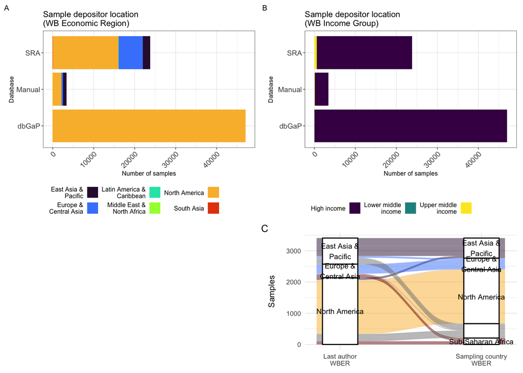

How overrepresented are these numbers? We begin by grabbing the UN population data:

```r
worldPop <- read.csv("RNA-seq-diversity_world-population.csv")
worldPop$name <- gsub("Korea, South", "South Korea", worldPop$name)

allCountry2 <- allCountry %>%
  group_by(finalCountry, db, worldRegion) %>%
  summarise(value = sum(value)) %>%
  as.data.frame()
```

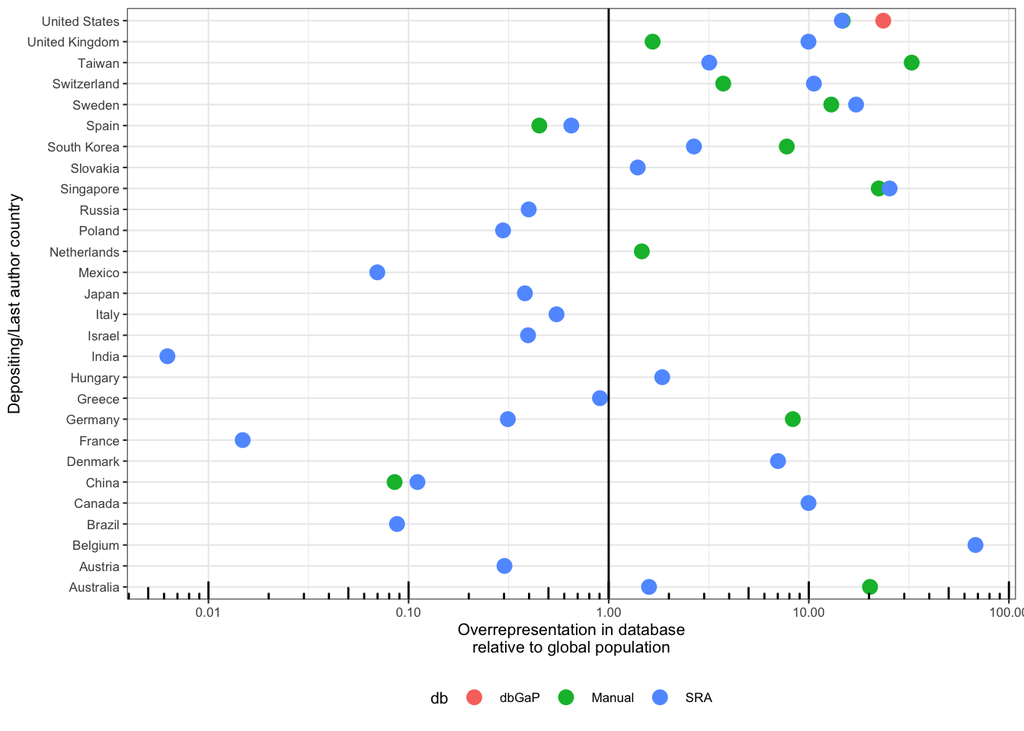

```r
allCountry3 <- left_join(allCountry2, worldPop, join_by( "finalCountry" == "name"))

# And now we get some fancy new columns for plotting
allCountry3 <- allCountry3 %>%
  mutate(fractPop = value.y/sum(worldPop$value)) %>%
  group_by(db) %>%
  mutate(fractDB = value.x/sum(value.x)) %>%
  mutate(excess = fractDB/fractPop) %>%
  as.data.frame()

ggplot(allCountry3, aes(x = excess, y=finalCountry, color=db)) +
  geom_point(size = 3) +
  scale_x_continuous(trans='log10', breaks = trans_breaks("log10", function(x) 10^x), labels = scales::comma) +
  geom_vline(xintercept = 1) +
  annotation_logticks(sides="b") +
  xlab("Overrepresentation in database\nrelative to global population") +
  ylab("Depositing/Last author country") +
  theme_bw(base_size = 8) +
  theme(legend.title.align = 1, legend.direction = "horizontal", legend.background=element_blank(), legend.position="bottom")
```

```r
ggsave("db_overrepresentation.pdf", width = 3, height = 8)
ggsave("db_overrepresentation.png", width = 3, height = 8)
```

And now we’re making a map with all of this…

```r
toplot<-aggregate(BioSample~finalCountry,data=allSRAFinal,FUN=length)
colnames(toplot) <- c('name','samples')
toplot$name[which(toplot$name=='USA')]<-'United States of America'
toplot$name[which(toplot$name=='UK')]<-'United Kingdom'
toplot$name[which(toplot$name=='Hong Kong SAR')]<-'Hong Kong'
toplot$name[which(toplot$name=='Korea')]<-'South Korea' #???

toplot2 <- ne_countries(scale='medium', returnclass = 'sf') %>%
  left_join(toplot, by = 'name')
toplot2$samples[which(is.na(toplot2$samples))]<-0

# check for any that failed to merge
toplot$name[-which(toplot$name %in% toplot2$name)]
```

```
## character(0)
```

```r
tmp<-subset(toplot2,samples>0)
table(tmp$income_grp)
```

```
##
##    1. High income: OECD 2. High income: nonOECD  3. Upper middle income  4. Lower middle income
##                      20                       2                       4                       1
```

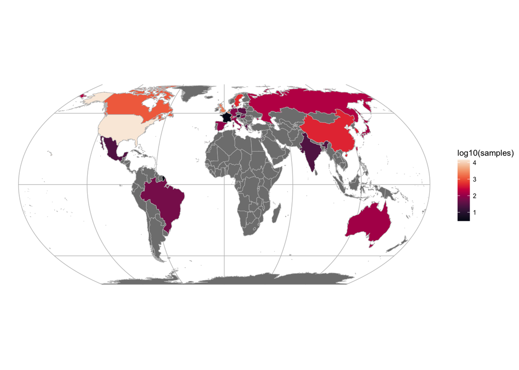

```r
ggplot(data=toplot2) +
  geom_sf(aes(fill=log10(samples)), color='grey', size=0.1) +
  coord_sf(crs = "+proj=eqearth +wktext") +
  scale_fill_viridis(option="rocket", na.value = "grey50") +
  theme(panel.grid.major = element_line(linewidth = 0.25, linetype = 'solid', color = "grey"),
        panel.border = element_blank(),
        axis.text.x=element_blank(),
        axis.ticks.x=element_blank()
  )
```

```r
ggsave("all_dbs_sample_properties_only_map.pdf", width = 4, height = 4)
```

## 2. Sample breakdown by descriptor

Making main text figure 2 - ancestry breakdown for all comparisons

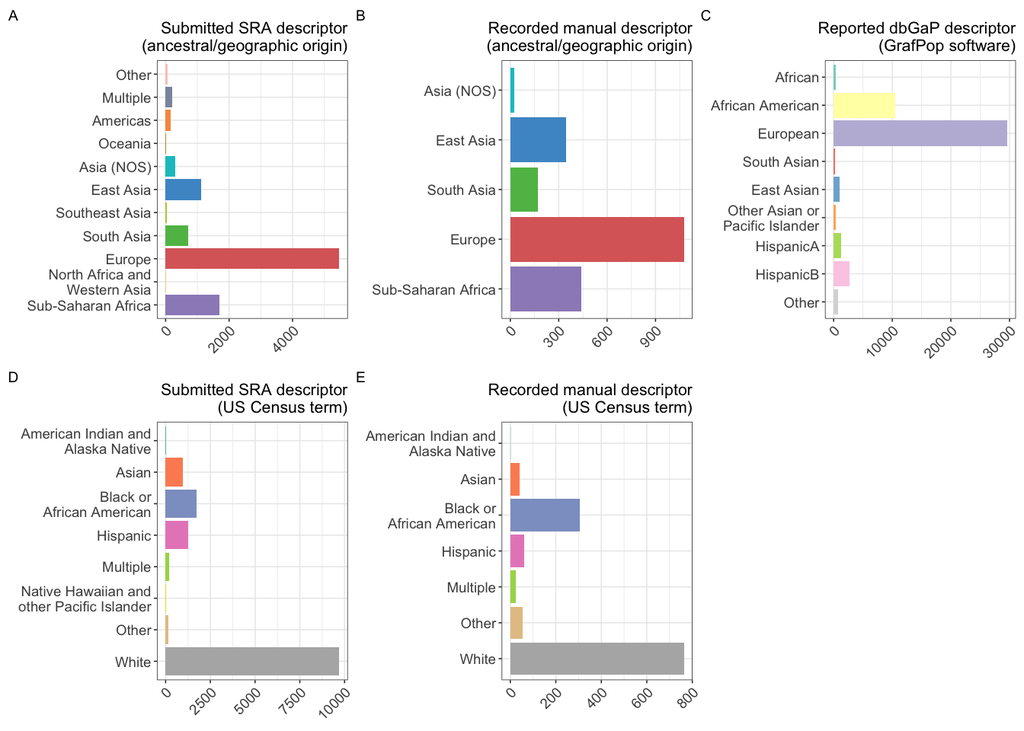

```r
geographyProp <- allSRAFinal %>% drop_na(strictestGeography) %>% count(strictestGeography) %>% mutate(freq = n/sum(n))
raceProp <- allSRAFinal %>% drop_na(strictestRace) %>% count(strictestRace) %>% mutate(freq = n/sum(n))

dbgapProp <- dbGapFinal %>% group_by(variable) %>% summarise(n = sum(value)) %>% mutate(freq = n/sum(n))

litRevGeoProp <- litRevFinal %>% drop_na(finalGeo) %>% group_by(finalGeo) %>% summarise(n = sum(individs)) %>% mutate(freq = n/sum(n))
litRevRaceProp <- litRevFinal %>% drop_na(finalRace) %>% group_by(finalRace) %>% summarise(n = sum(individs)) %>% mutate(freq = n/sum(n))

geoPlot <- ggplot(geographyProp, aes(x = fct_inorder(strictestGeography), y = n, fill = strictestGeography)) +
  geom_bar(stat="identity") +
  ggtitle("Submitted SRA descriptor\n(ancestral/geographic origin)") +
  xlab(NULL) +
  ylab(NULL) +
  coord_flip() +
  scale_fill_geography() +
  theme(axis.text.x = element_text(angle = 45, hjust=1)) +
  theme(legend.position="none") +
  theme(plot.title = element_text(hjust = 1))

racePlot <- ggplot(raceProp, aes(x = fct_rev(fct_inorder(strictestRace)), y = n, fill=strictestRace)) +
  geom_bar(stat="identity") +
  ggtitle("Submitted SRA descriptor\n(US Census term)") +
  xlab(NULL) +
  ylab(NULL) +
  coord_flip() +
  scale_fill_race() +
  theme(axis.text.x = element_text(angle = 45, hjust=1)) +
  theme(legend.position="none") +
  theme(plot.title = element_text(hjust = 1))

litRevGeoPlot <- ggplot(litRevGeoProp, aes(x = fct_inorder(finalGeo), y = n, fill = finalGeo)) +
  geom_bar(stat="identity") +
  ggtitle("Recorded manual descriptor\n(ancestral/geographic origin)") +
  xlab(NULL) +
  ylab(NULL) +
  coord_flip() +
  scale_fill_geography() +
  theme(axis.text.x = element_text(angle = 45, hjust=1)) +
  theme(legend.position="none") +
  theme(plot.title = element_text(hjust = 1))

litRevRacePlot <- ggplot(litRevRaceProp, aes(x = fct_rev(fct_inorder(finalRace)), y = n, fill=finalRace)) +
  geom_bar(stat="identity") +
  ggtitle("Recorded manual descriptor\n(US Census term)") +
  xlab(NULL) +
  ylab(NULL) +
  coord_flip() +
  scale_fill_race() +
  theme(axis.text.x = element_text(angle = 45, hjust=1)) +
  theme(legend.position="none") +
  theme(plot.title = element_text(hjust = 1))

dbgapPlot <- ggplot(dbgapProp, aes(x = fct_rev(fct_inorder(variable)), y = n, fill=variable)) +
  geom_bar(stat="identity") +
  ggtitle("Reported dbGaP descriptor\n(GrafPop software)") +
  xlab(NULL) +
  ylab(NULL) +
  coord_flip() +
  scale_fill_dbGap() +
  theme(axis.text.x = element_text(angle = 45, hjust=1)) +
  theme(legend.position="none") +
  theme(plot.title = element_text(hjust = 1))

geoPlot + litRevGeoPlot + dbgapPlot + racePlot + litRevRacePlot +
    plot_layout(design = long6Design, tag_level = 'new') +
    plot_annotation(tag_levels = 'A')
```

```r
# Because this figure has been cleaned up already...
ggsave("all_dbs_descriptors.pdf", width = 7, height = 4.5)
ggsave("all_dbs_descriptors.png", width = 7, height = 4.5)
```

```r
worldPop <- left_join(worldPop, toplot2[,c(19,93:96)], by = "name")
worldPop <- worldPop[,-8]

worldPopNA <- worldPop[is.na(worldPop$subregion),]
worldPopOk <- worldPop %>% filter(!is.na(subregion))

worldPopNA <- worldPopNA %>%
  mutate(subregion = ifelse(grepl("America", region), "Americas", subregion)) %>%
  mutate(subregion = ifelse(grepl("Australia and Oceania", region), "Oceania", subregion)) %>%
  mutate(subregion = ifelse(grepl("Europe", region), "Europe", subregion)) %>%
  mutate(subregion = ifelse(grepl("Middle East", region), "North AF and WA", subregion)) %>%
  mutate(subregion = ifelse(grepl("Africa", region), "Sub-Saharan Africa", subregion)) %>%
  mutate(subregion = ifelse(grepl("Korea, North|Macau|Paracel", name), "East Asia", subregion)) %>%
  mutate(subregion = ifelse(grepl("Burma", name), "Southeast Asia", subregion))

worldPop2 <- rbind(worldPopNA, worldPopOk)
```

… and we stop there until we work out what to do with all the Europeans outside Europe!

Lol the internet suggested just adding the number of Europeans outside Europe, and the best source I could find was the Wikipedia page on the European diaspora (at least I saved it to Zotero. Technically should be able to read in those numbers and, uh, substract them from the countries, and recompute stuff? But that is such BS…)

I removed overseas holdings of European countries to avoid double counting (Ceuta, Melilla, New Caledonia, etc), and also countries that the world bank says are European (Russia, one of the stans)

```r
euros <- read.csv("20240901_European_diaspora_data.csv")
africans <- read.csv("20240901_African_diaspora_data.csv")

# Let's drop the mixed ones? I don't know what to do with them... If I don't I end up double-counting a LOT of Brazilians
euros <- euros %>% filter(!grepl("mixed", Note))
africans <- africans %>% filter(!grepl("mixed", Note)) %>%
  mutate(Country = ifelse(grepl("Turkey", Country), "Turkey (Turkiye)", Country))

worldPop3 <- left_join(worldPop2, euros, join_by("name" == "Country") )
worldPop3 <- left_join(worldPop3, africans, join_by("name" == "Country") )

worldPop3 <- worldPop3 %>%
  mutate(European = ifelse(is.na(European), 0, European)) %>%
  mutate(African = ifelse(is.na(African), 0, African)) %>%
  mutate(nonEuroPop = value - European) %>%
  mutate(nonAFR = value - African) %>%
  mutate(noneither = value - European - African)

head(worldPop3)
```

```
##                                name     value                  region continent region_un          subregion region_wb  European Note.x  African Note.y nonEuroPop    nonAFR
## 1                     United States 341963408           North America      <NA>      <NA>           Americas      <NA> 204277273        41104200         137686135 300859208
## 2 Congo, Democratic Republic of the 115403027                  Africa      <NA>      <NA> Sub-Saharan Africa      <NA>         0   <NA>        0   <NA>  115403027 115403027
## 3                  Turkey (Turkiye)  84119531             Middle East      <NA>      <NA>    North AF and WA      <NA>         0   <NA>   100000          84119531  84019531
## 4                             Burma  57527139 East and Southeast Asia      <NA>      <NA>     Southeast Asia      <NA>         0   <NA>        0   <NA>   57527139  57527139
## 5                     Cote d'Ivoire  29981758                  Africa      <NA>      <NA> Sub-Saharan Africa      <NA>         0   <NA>        0   <NA>   29981758  29981758
## 6                      Korea, North  26298666 East and Southeast Asia      <NA>      <NA>          East Asia      <NA>         0   <NA>        0   <NA>   26298666  26298666
##   noneither
## 1  96581935
## 2 115403027
## 3  84019531
## 4  57527139
## 5  29981758
## 6  26298666
```

```r
regionalPop <- worldPop3 %>% group_by(subregion) %>%
  summarise(population = sum(value), euro = sum(European), noneuro = sum(nonEuroPop), afr = sum(African), nonafr = sum(nonAFR), others = sum(noneither)) %>% as.data.frame()

# This also needs a bit more cleaning:
regionalPop <- regionalPop %>%
  mutate(subregion = gsub("Northern Africa|Western Asia", "North AF and WA", subregion)) %>%
  mutate(subregion = ifelse(grepl("Africa", subregion), "Sub-Saharan Africa", subregion)) %>%
  mutate(subregion = ifelse(grepl("Europe", subregion), "Europe", subregion)) %>%
  mutate(subregion = ifelse(grepl("America", subregion), "Americas", subregion)) %>%
  mutate(subregion = gsub("Australia and New Zealand|Melanesia|Micronesia|Polynesia", "Oceania", subregion)) %>%
  mutate(subregion = gsub("Caribbean", "Americas", subregion)) %>%
  mutate(subregion = gsub("South-Eastern Asia", "Southeast Asia", subregion)) %>%
  mutate(subregion = gsub("Eastern Asia", "East Asia", subregion)) %>%
  mutate(subregion = gsub("Southern Asia", "South Asia", subregion)) %>%
  mutate(subregion = gsub("North AF and WA", "North Africa and\nWestern Asia", subregion)) %>%
  group_by(subregion) %>% summarise(population = sum(population), euro = sum(euro), noneuro = sum(noneuro), afr = sum(afr), nonafr = sum(nonafr), others = sum(others))

regionalPop
```

```
## # A tibble: 9 × 7
##   subregion                        population      euro    noneuro      afr     nonafr     others
##   <chr>                                 <int>     <dbl>      <dbl>    <dbl>      <dbl>      <dbl>
## 1 "Americas"                       1047819112 487053967  560765145 89528554  958290558  471236591
## 2 "Central Asia"                     79090914   4088763   75002151        0   79090914   75002151
## 3 "East Asia"                      1652446317         0 1652446317        0 1652446317 1652446317
## 4 "Europe"                          742084882         0  742084882 11458076  730626806  730626806
## 5 "North Africa and\nWestern Asia"  556654119   2800000  553854119 10010000  546644119  543844119
## 6 "Oceania"                          45531556  25183742   20347814   326673   45204883   20021141
## 7 "South Asia"                     2013075939         0 2013075939   269514 2012806425 2012806425
## 8 "Southeast Asia"                  700655943         0  700655943        0  700655943  700655943
## 9 "Sub-Saharan Africa"             1219894219   4954252 1214939967        0 1219894219 1214939967
```

```r
# And now we're finally ready to compare things!
regionalPop2 <- regionalPop %>%
  mutate(euro = ifelse(grepl("Europe", subregion), population - afr, euro)) %>%
  mutate(afr = ifelse(grepl("Sub-Saharan Africa", subregion), population - euro, afr)) %>%
  mutate(global = ifelse(grepl("Sub-Saharan Africa", subregion), sum(afr), others)) %>%
  mutate(global = ifelse(grepl("Europe", subregion), sum(euro), global)) %>%
  mutate(fractPop = global/sum(global)) %>%
  mutate(sanityCheck = euro + afr + global - population)

regionalPop2 # that gets me to 15.6% for Europe... so we'll go with that even though it's terrible
```

```
## # A tibble: 9 × 10
##   subregion                        population      euro    noneuro        afr     nonafr     others     global fractPop sanityCheck
##   <chr>                                 <int>     <dbl>      <dbl>      <dbl>      <dbl>      <dbl>      <dbl>    <dbl>       <dbl>
## 1 "Americas"                       1047819112 487053967  560765145   89528554  958290558  471236591  471236591  0.0585            0
## 2 "Central Asia"                     79090914   4088763   75002151          0   79090914   75002151   75002151  0.00931           0
## 3 "East Asia"                      1652446317         0 1652446317          0 1652446317 1652446317 1652446317  0.205             0
## 4 "Europe"                          742084882 730626806  742084882   11458076  730626806  730626806 1254707530  0.156    1254707530
## 5 "North Africa and\nWestern Asia"  556654119   2800000  553854119   10010000  546644119  543844119  543844119  0.0675            0
## 6 "Oceania"                          45531556  25183742   20347814     326673   45204883   20021141   20021141  0.00248           0
## 7 "South Asia"                     2013075939         0 2013075939     269514 2012806425 2012806425 2012806425  0.250             0
## 8 "Southeast Asia"                  700655943         0  700655943          0  700655943  700655943  700655943  0.0870            0
## 9 "Sub-Saharan Africa"             1219894219   4954252 1214939967 1214939967 1219894219 1214939967 1326532784  0.165    1326532784
```

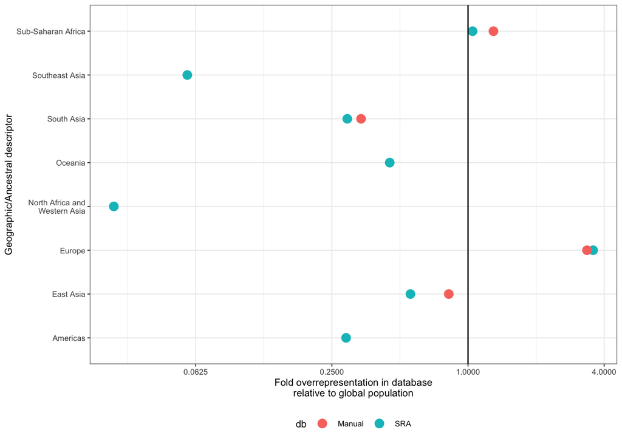

```r
geographyProp <- left_join(geographyProp, regionalPop2, join_by( "strictestGeography" == "subregion"))
litRevGeoProp <- left_join(litRevGeoProp, regionalPop2, join_by( "finalGeo" == "subregion"))

geographyProp$db <- "SRA"
litRevGeoProp$db <- "Manual"
names(litRevGeoProp)[1] <- "strictestGeography"

allGeoProps <- rbind(geographyProp, litRevGeoProp)
allGeoProps <- allGeoProps %>%
  filter(!is.na(population)) %>%
  mutate(excess = freq/fractPop)

ggplot(allGeoProps, aes(x = excess, y=strictestGeography, color=db)) +
  geom_point(size = 3) +
  # scale_x_continuous(trans='log2', breaks = trans_breaks("log2", function(x) 2^x), labels = trans_format("log2", math_format(2^.x))) +
  scale_x_continuous(trans='log2', breaks = trans_breaks("log2", function(x) 2^x)) +
  geom_vline(xintercept = 1) +
  # annotation_logticks(sides="b") +
  xlab("Fold overrepresentation in database\nrelative to global population") +
  ylab("Geographic/Ancestral descriptor") +
  theme_bw(base_size = 8) +
  theme(legend.title.align = 1, legend.direction = "horizontal", legend.background=element_blank(), legend.position="bottom")
```

```r
ggsave("global_overrepresentation.pdf", width = 3, height = 5)
ggsave("global_overrepresentation.png", width = 3, height = 5)
```

Let’s move onto the US census, which is a lot easier

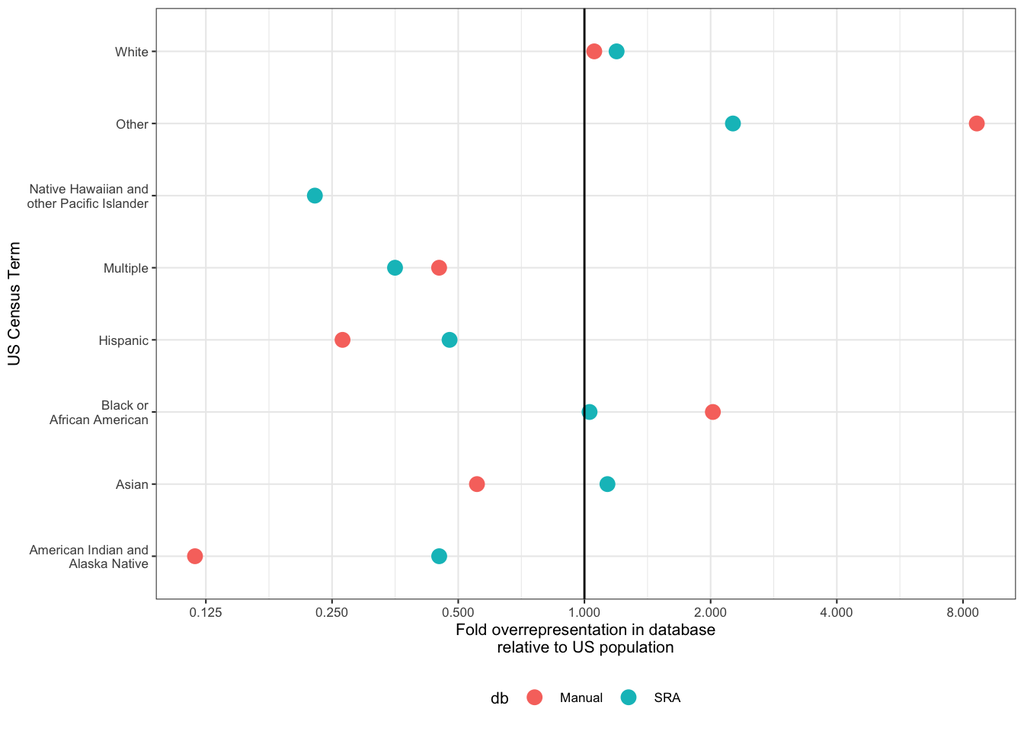

```r
uscensus <- read.csv("RNA-seq diversity - SI tables v2 - US census.csv")

# To make the merges work:
uscensus <- uscensus %>%
  mutate(Race = gsub(" alone", "", Race)) %>%
  mutate(Race = ifelse(is.na(Race), "Hispanic", Race)) %>%
  mutate(Race = gsub("and ", "and\n", Race)) %>%
  mutate(Race = gsub("or ", "or\n", Race)) %>%
  mutate(Race = gsub("\nOther", "\nother", Race)) %>%
  mutate(Race = gsub("More than 1 race", "Multiple", Race)) %>%
  mutate(Race = gsub("Some Other Race", "Other", Race))

raceProp <- left_join(raceProp, uscensus, join_by("strictestRace" == "Race"))
litRevRaceProp <- left_join(litRevRaceProp, uscensus, join_by("finalRace" == "Race"))

raceProp$db <- "SRA"
litRevRaceProp$db <- "Manual"
names(litRevRaceProp)[1] <- "strictestRace"

allRaceProps <- rbind(raceProp, litRevRaceProp)
allRaceProps$excess <- allRaceProps$freq/allRaceProps$Proportion.of.the.population

ggplot(allRaceProps, aes(x = excess, y=strictestRace, color=db)) +
  geom_point(size = 3) +
  # scale_x_continuous(trans='log2', breaks = trans_breaks("log2", function(x) 2^x), labels = trans_format("log2", math_format(2^.x))) +
  scale_x_continuous(trans='log2', breaks = trans_breaks("log2", function(x) 2^x)) +
  geom_vline(xintercept = 1) +
  # annotation_logticks(sides="b") +
  xlab("Fold overrepresentation in database\nrelative to US population") +
  ylab("US Census Term") +
  theme_bw(base_size = 8) +
  theme(legend.title.align = 1, legend.direction = "horizontal", legend.background=element_blank(), legend.position="bottom")
```

```r
ggsave("us_census_overrepresentation.pdf", width = 3, height = 5)
ggsave("us_census_overrepresentation.png", width = 3, height = 5)
```

Much easier…

And now, remaking the plot of samples by study across SRA and dbGaP

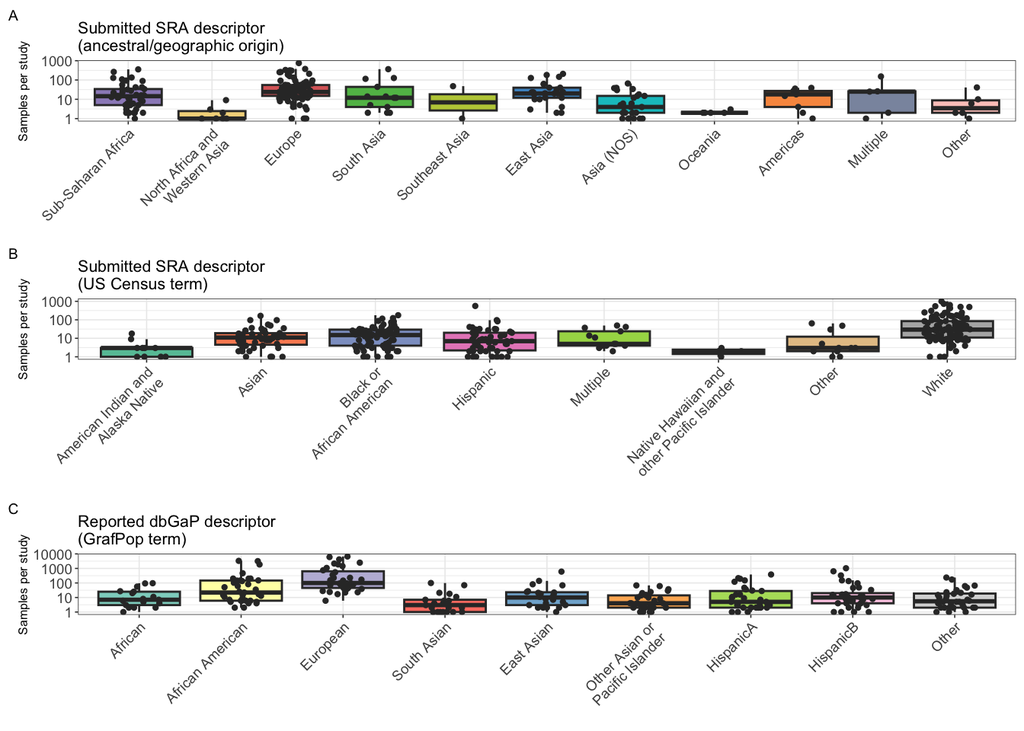

```r
sampleGeography <- allSRAFinal %>% count(SRA.Study, strictestGeography) %>% drop_na(strictestGeography)
sampleRace <- allSRAFinal %>% count(SRA.Study, strictestRace) %>% drop_na(strictestRace)
meltSampleGeography <- melt(sampleGeography)
meltSampleRace <- melt(sampleRace)
geobyStudy <- ggplot(meltSampleGeography, aes(x = strictestGeography, y=value,fill=strictestGeography)) +
  geom_boxplot(width=0.8, outlier.shape = NA) +
  geom_jitter(size=0.8, width=0.2, color="#333333") +
  ggtitle("Submitted SRA descriptor\n(ancestral/geographic origin)") +
  xlab("") +
  ylab("Samples per study") +
  scale_y_continuous(trans='log10') +
  scale_fill_geography() +
  theme(axis.text.x = element_text(angle = 45, hjust=1)) +
  theme(legend.position = "none")

racebyStudy <- ggplot(meltSampleRace, aes(x = strictestRace, y=value,fill=strictestRace)) +
  geom_boxplot(width=0.8, outlier.shape = NA) +
  geom_jitter(size=0.8, width=0.2, color="#333333") +
  ggtitle("Submitted SRA descriptor\n(US Census term)") +
  xlab("") +
  ylab("Samples per study") +
  scale_y_continuous(trans='log10') +
  scale_fill_race() +
  theme(axis.text.x = element_text(angle = 45, hjust=1)) +
  theme(legend.position = "none")

dbGapbyStudy <- dbGapFinal %>% filter(value > 0) %>%
  ggplot(., aes(x = variable, y=value,fill=variable)) +
  geom_boxplot(width=0.8, outlier.shape = NA) +
  geom_jitter(size=0.8, width=0.2, color="#333333") +
  ggtitle("Reported dbGaP descriptor\n(GrafPop term)") +
  xlab("") +
  ylab("Samples per study") +
  scale_y_continuous(trans='log10') +
  scale_fill_dbGap() +
  theme(axis.text.x = element_text(angle = 45, hjust=1)) +
  theme(legend.position = "none")

geobyStudy + racebyStudy + dbGapbyStudy +
  plot_layout(design = wide3Design) +
  plot_annotation(tag_levels = 'A')
```

```r
ggsave("fig2_by_study_boxplot_all.pdf", width=6.5, height=8)
ggsave("fig2_by_study_boxplot_all.png", width=6.5, height=8)
```